# Testing extreme cases for the derivative simulation

```r
invisible(lapply(dir("R", full.names = TRUE), source)) # Load functions
```

Some extreme cases for the first derivative in simulation:

```r
excases <- function(no) {
  switch(no,
         dirmix(c(1.2, 7, 4)),
         dirmix(c(1.7, 7, 4)),
         dirmix(c(2, 7, 4)), # mode = c(0.1, 0.6, 0.3); h = 0.1
         dirmix(c(3, 7, 4)),
         dirmix(c(3, 13, 7)), # mode = c(0.1, 0.6, 0.3); h = 0.05
         dirmix(c(6, 31, 16)) # mode = c(0.1, 0.6, 0.3); h = 0.01
         )
}
```

Simulation function:

```r
exsimu <- function(mix, seed, n = 500, rep = 5) {
  samp <- DIE_samp(mix, 1e4) # Generate monte Carlo samples
  iae <- ise <- NULL
  for (i in 1:rep) {
    cat(i, " ")
    set.seed(seed[i])
    x <- rdirmix(n, mix)
    fm <- optfm(x)
    fmb <- optfm(x, bound = 1.51)

    # ==== Bandwidth from derivative ====
    # Alpha of finite mixture must > 1.5 to ensure L2 integrability of KDE in first derivative
    # c = 1.5
    c <- 1.5
    pih <- optMISEh(fmb$mix, n, 1)
    knpi <- dirkn(x, pih$h, c)
    cvh <- optLSCVh(x, 1)
    kncv <- dirkn(x, cvh$h, c)
    # c can not be 1.5 in KDE if x contains 0, since alpha = x/h + c should > 1.5
    c <- 1.75
    cvh1 <- optLSCVh(x, 1, c = c)
    kncv1 <- dirkn(x, cvh1$h, c)
    c <- 2
    cvh2 <- optLSCVh(x, 1, c = c)
    kncv2 <- dirkn(x, cvh2$h, c)

    # ==== Bandwidth from density ====
    pih_den <- optMISEh(fmb$mix, n)
    knpi_den <- dirkn(x, pih_den$h)
    cvh_den <- optLSCVh(x)
    kncv_den <- dirkn(x, cvh_den$h)
    lkh_den  <- optLCVh(x)
    knlk_den <- dirkn(x, lkh_den$h)

    IEfm <- DIE(samp, fm$mix)
    IEfmb <- DIE(samp, fmb$mix)
    IEpi <- DIE(samp, knpi)
    IEcv <- DIE(samp, kncv)
    IEcv1 <- DIE(samp, kncv1)
    IEcv2 <- DIE(samp, kncv2)
    IEpi_den <- DIE(samp, knpi_den)
    IEcv_den <- DIE(samp, kncv_den)
    IElk_den <- DIE(samp, knlk_den)
    h <- c(pih$h, cvh$h, cvh1$h, cvh2$h, pih_den$h, cvh_den$h, lkh_den$h)
    viae <- c(seed[i], IEfm$iae, IEfmb$iae, IEpi$iae, IEcv$iae, IEcv1$iae, IEcv2$iae,
              IEpi_den$iae, IEcv_den$iae, IElk_den$iae)
    vise <- c(seed[i], IEfm$ise, IEfmb$ise, IEpi$ise, IEcv$ise, IEcv1$ise, IEcv2$ise,
              IEpi_den$ise, IEcv_den$ise, IElk_den$ise)
    iae <- rbind(iae, c(viae, h))
    ise <- rbind(ise, c(vise, h))
  }
  colnames(iae) <- colnames(ise) <- c("seed", "fm", "fm1.5", "PI", "CV", "CV1.75", "CV2", "PI_den", "CV_den", "LK_den",
                                      "PIh", "CVh", "CV1.75h", "CV2h", "PIh_den", "CVh_den", "LKh_den")
  list(iae = iae, ise = ise)
}
```

Some basic setting for simulation:

```r
n <- 500
rep <- 5
seed <- ceiling(runif(rep, 1, 1e5))
```

## Model 1:

Alpha <= 1.5 of the test Dirichlet distribution.

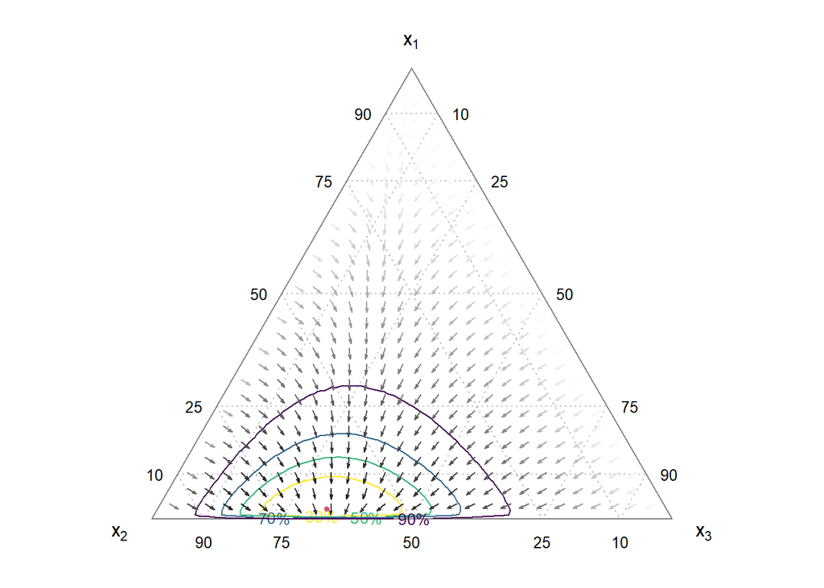

```r
mix <- excases(1)
plotdg(mix)
```

```r
re1 <- exsimu(mix, seed, n, rep)
```

```
## 1  2  3  4  5
```

Simulation results:

```r
re1
```

```
## $iae
##       seed       fm    fm1.5       PI       CV   CV1.75      CV2   PI_den
## [1,] 79856 1.425916 7.765501 21.27578 12.45072 13.72041 14.58151 8.948690
## [2,] 11223 2.479722 8.410657 21.17551 51.92640 52.42626 52.13894 8.374600
## [3,]  4892 2.645724 7.095226 21.23584 11.54179 12.63672 22.90256 6.908249
## [4,] 80128 1.564328 7.510142 21.24838 12.24959 13.86550 14.99833 8.508058
## [5,] 83991 1.919641 7.658290 21.22818 13.04609 14.55728 16.06392 9.649565
##        CV_den   LK_den       PIh         CVh     CV1.75h        CV2h
## [1,] 8.926114 7.982120 0.9996009 0.007952217 0.007954036 0.009841873
## [2,] 7.550569 7.062943 0.9996009 0.001399071 0.001399071 0.001399071
## [3,] 6.692524 6.771697 0.9996009 0.007069946 0.006957347 0.999600944
## [4,] 9.365980 8.814000 0.9996009 0.008714877 0.007443402 0.007252292
## [5,] 9.660845 8.540232 0.9996009 0.007525830 0.006686641 0.006019974
##          PIh_den     CVh_den    LKh_den
## [1,] 0.009930905 0.009983501 0.01448389
```

[output cut: 24 more lines]

When density close to the boundary. It means that our finite mixture’s alpha < 1.5.

If we force the finite mixture’s alpha > 1.5, the estimation of the finite mixture will be bad. (fm1.5 >> fm)

Since Plug-in method highly depends on fm1.5, its results also bad, and its bandwidth close to 1 (why?).

CV method is not rely on finite mixture. It is better than PI, but compared with other results, CV is still bad. And as c increases, the results getting worse.

Density based PI and CV selectors are even better than derivative-based ones.

Alpha = 1.7 of the test Dirichlet distribution.

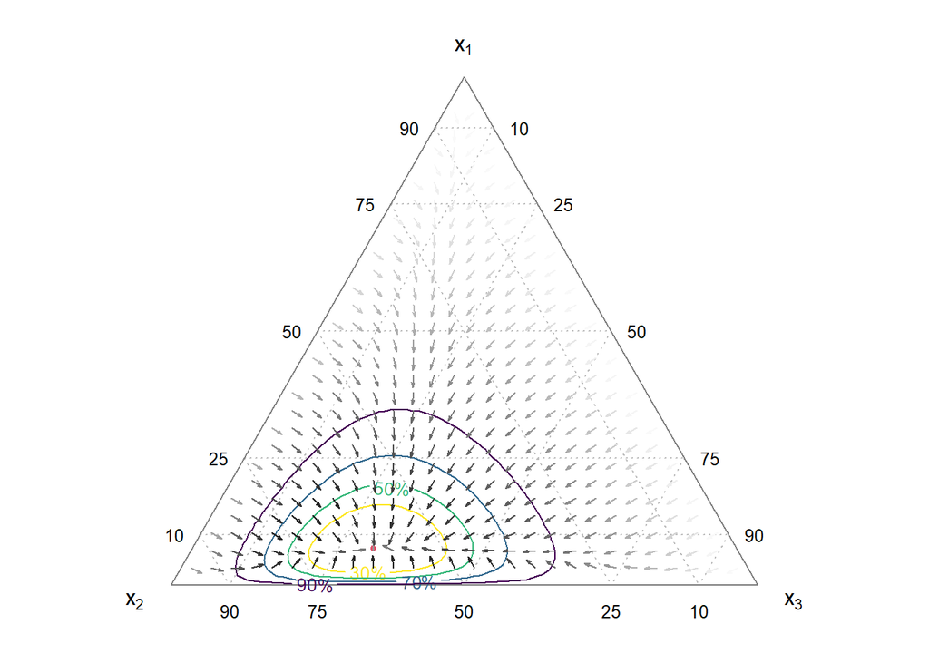

```r
mix <- excases(2)
plotdg(mix)
```

```r
re2 <- exsimu(mix, seed, n, rep)
```

```
## 1  2  3  4  5
```

Simulation results:

```r
lapply(re2, function(i) i[, !colnames(i) %in% c("CV1.75", "CV2", "CV1.75h", "CV2h")])
```

```
## $iae
##       seed        fm     fm1.5       PI        CV   PI_den   CV_den   LK_den
## [1,] 79856 1.2115168 1.2115168 6.308692  7.669576 5.139547 5.064008 4.935875
## [2,] 11223 1.6045510 1.6045510 6.008334 11.756586 3.884016 4.073362 4.384591
## [3,]  4892 0.6799029 0.6799029 4.833080 10.143928 5.676232 4.720835 5.077897
## [4,] 80128 1.0211646 1.0211646 5.914256  6.603780 4.266010 4.272318 4.518902
## [5,] 83991 1.8468003 1.8468003 6.824177  6.802276 5.901140 7.165893 5.949395
##             PIh         CVh    PIh_den     CVh_den    LKh_den
## [1,] 0.01632062 0.035407412 0.01414246 0.014736654 0.01626634
## [2,] 0.01315245 0.005065756 0.01585488 0.014809959 0.01346809
## [3,] 0.01380913 0.006019974 0.01109827 0.014142462 0.01270898
## [4,] 0.01287857 0.010123789 0.01621169 0.016136651 0.01414246
## [5,] 0.01591334 0.016690371 0.01308508 0.009547808 0.01288167
##
## $ise
##       seed        fm     fm1.5       PI       CV    PI_den    CV_den   LK_den
## [1,] 79856 24.881060 24.881060 452.7939 576.8024 185.50385 182.78027 177.9686
## [2,] 11223 18.759955 18.759955 491.2459 881.9766 120.46061 134.30950 157.7447
## [3,]  4892  4.734875  4.734875 251.7681 587.9747 226.44289 179.84071 195.3128
## [4,] 80128  5.622306  5.622306 388.0992 406.1896  95.55719  95.68018 102.7645
## [5,] 83991 67.917135 67.917135 516.5636 520.9747 269.42951 333.40601 271.8385
##             PIh         CVh    PIh_den     CVh_den    LKh_den
## [1,] 0.01632062 0.035407412 0.01414246 0.014736654 0.01626634
## [2,] 0.01315245 0.005065756 0.01585488 0.014809959 0.01346809
## [3,] 0.01380913 0.006019974 0.01109827 0.014142462 0.01270898
## [4,] 0.01287857 0.010123789 0.01621169 0.016136651 0.01414246
## [5,] 0.01591334 0.016690371 0.01308508 0.009547808 0.01288167
```

Since alpha > 1.5 for the test model, the alpha of finite mixture estimation will not outside the boundary, thus the results of fm and fm1.5 is the same.

Density based PI and CV selectors still better than derivative-based ones, but the differences get narrowed.

## Model 3:

Alpha = 2 of the test Dirichlet distribution.

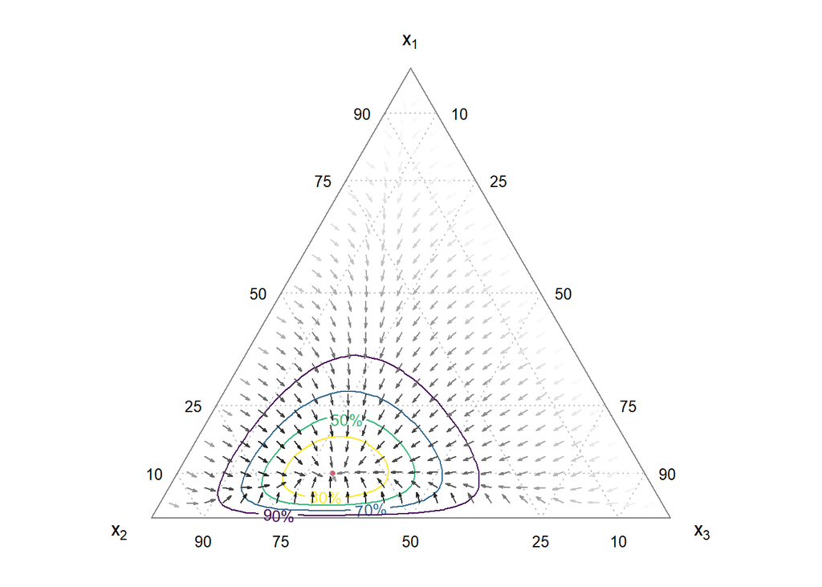

```r
mix <- excases(3)
plotdg(mix)
```

```r
re3 <- exsimu(mix, seed, n, rep)
```

```
## 1  2  3  4  5
```

```r
lapply(re3, function(i) i[, !colnames(i) %in% c("fm1.5", "CV1.75", "CV2", "CV1.75h", "CV2h")])
```

```
## $iae
##       seed        fm       PI       CV   PI_den   CV_den   LK_den        PIh
## [1,] 79856 0.6582242 4.595476 4.911768 4.269693 4.100827 4.118348 0.02053609
## [2,] 11223 2.9768900 4.364061 4.250810 4.863669 4.644805 5.323527 0.01462342
## [3,]  4892 0.6442113 4.104030 6.081424 4.407877 4.251140 4.757997 0.01576093
## [4,] 80128 1.1409125 4.868501 4.665050 4.184663 4.000909 4.101767 0.01469472
## [5,] 83991 1.3482711 5.369881 5.350831 5.302388 6.138609 5.648480 0.01814317
##              CVh    PIh_den    CVh_den    LKh_den
## [1,] 0.027616021 0.01447580 0.01609832 0.01587873
## [2,] 0.015072817 0.01209352 0.01261064 0.01111121
## [3,] 0.008752739 0.01447580 0.01604869 0.01255980
## [4,] 0.018586680 0.01505408 0.01663590 0.01569329
## [5,] 0.018928213 0.01294792 0.01050727 0.01176806
##
## $ise
##       seed        fm        PI        CV    PI_den    CV_den    LK_den
## [1,] 79856  3.236251  92.23120 106.59379  59.24580  56.12760  56.37385
## [2,] 11223 29.869283  72.80380  70.26535  69.07294  62.81124  83.58658
## [3,]  4892  1.073330  59.63443 130.27306 103.31551 106.81551 104.65800
## [4,] 80128  4.917999  98.78356  96.32974  55.83869  53.04289  54.36079
## [5,] 83991 12.468442 120.93838 121.29376  94.00194 115.76697 102.48678
##             PIh         CVh    PIh_den    CVh_den    LKh_den
## [1,] 0.02053609 0.027616021 0.01447580 0.01609832 0.01587873
## [2,] 0.01462342 0.015072817 0.01209352 0.01261064 0.01111121
## [3,] 0.01576093 0.008752739 0.01447580 0.01604869 0.01255980
## [4,] 0.01469472 0.018586680 0.01505408 0.01663590 0.01569329
## [5,] 0.01814317 0.018928213 0.01294792 0.01050727 0.01176806
```

Density based PI and CV selectors perform similar to derivative-based ones now.

## Model 4:

Alpha = 3 of the test Dirichlet distribution.

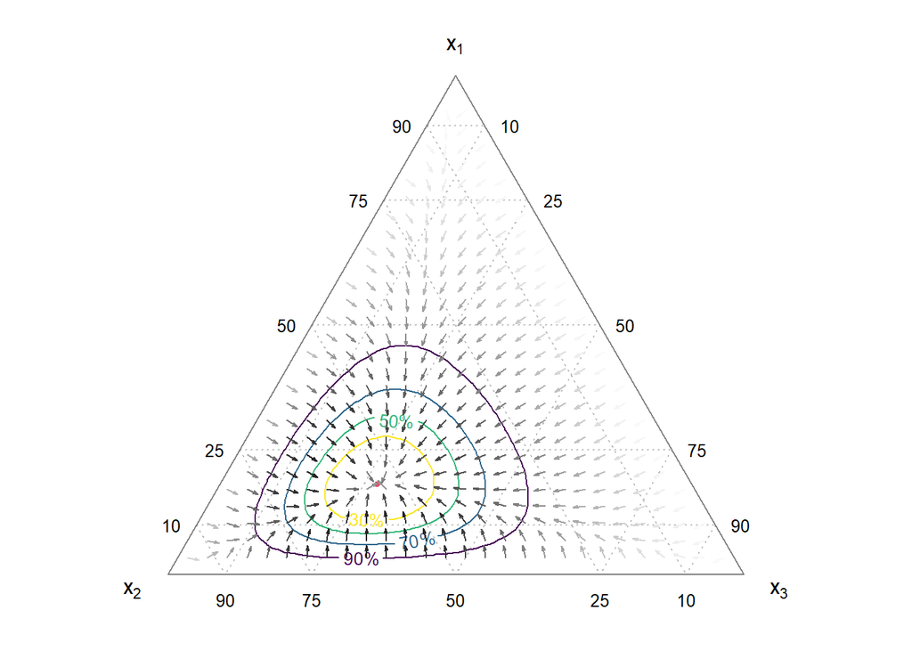

```r
mix <- excases(4)
plotdg(mix)
```

```r
re4 <- exsimu(mix, seed, n, rep)
```

```
## 1  2  3  4  5
```

```r
lapply(re4, function(i) i[, !colnames(i) %in% c("fm1.5", "CV1.75", "CV2", "CV1.75h", "CV2h")])
```

```
## $iae
##       seed        fm       PI       CV   PI_den   CV_den   LK_den        PIh
## [1,] 79856 1.2035909 3.520295 6.121853 4.251499 5.702045 4.287721 0.02159828
## [2,] 11223 2.1405574 2.191834 2.116884 3.790213 3.118602 3.118602 0.02028118
## [3,]  4892 1.3272287 3.447249 3.947116 3.809450 3.705061 3.699150 0.02443610
## [4,] 80128 0.1667252 3.080106 3.104901 4.669440 4.154488 3.766896 0.02226495
## [5,] 83991 1.3002934 3.045364 3.122532 4.269578 4.689535 3.667978 0.02528943
##              CVh    PIh_den     CVh_den    LKh_den
## [1,] 0.008789155 0.01380913 0.009663691 0.01362832
## [2,] 0.024586660 0.01140066 0.013809128 0.01380913
## [3,] 0.034714939 0.01380913 0.018593449 0.01607003
## [4,] 0.025316754 0.01124469 0.013475795 0.01792960
## [5,] 0.019249964 0.01214004 0.010902601 0.01471761
##
## $ise
##       seed         fm        PI        CV   PI_den   CV_den   LK_den        PIh
## [1,] 79856 3.15857014 25.057314 84.248901 39.28540 72.31794 40.00841 0.02159828
## [2,] 11223 9.94970948  8.764882  7.650552 29.00715 19.37453 19.37453 0.02028118
## [3,]  4892 3.20971301 21.990258 27.558741 31.63269 29.10784 29.49467 0.02443610
## [4,] 80128 0.05767303 19.566230 19.821146 48.09491 37.73472 30.36648 0.02226495
## [5,] 83991 3.78463826 16.871198 18.115012 34.53936 42.46418 24.94410 0.02528943
##              CVh    PIh_den     CVh_den    LKh_den
## [1,] 0.008789155 0.01380913 0.009663691 0.01362832
## [2,] 0.024586660 0.01140066 0.013809128 0.01380913
## [3,] 0.034714939 0.01380913 0.018593449 0.01607003
## [4,] 0.025316754 0.01124469 0.013475795 0.01792960
## [5,] 0.019249964 0.01214004 0.010902601 0.01471761
```

In this case, derivative-based PI and CV selectors are better, just worse than fm.

## Model 5:

Mode is the same as model 3, but alpha_0 is larger.

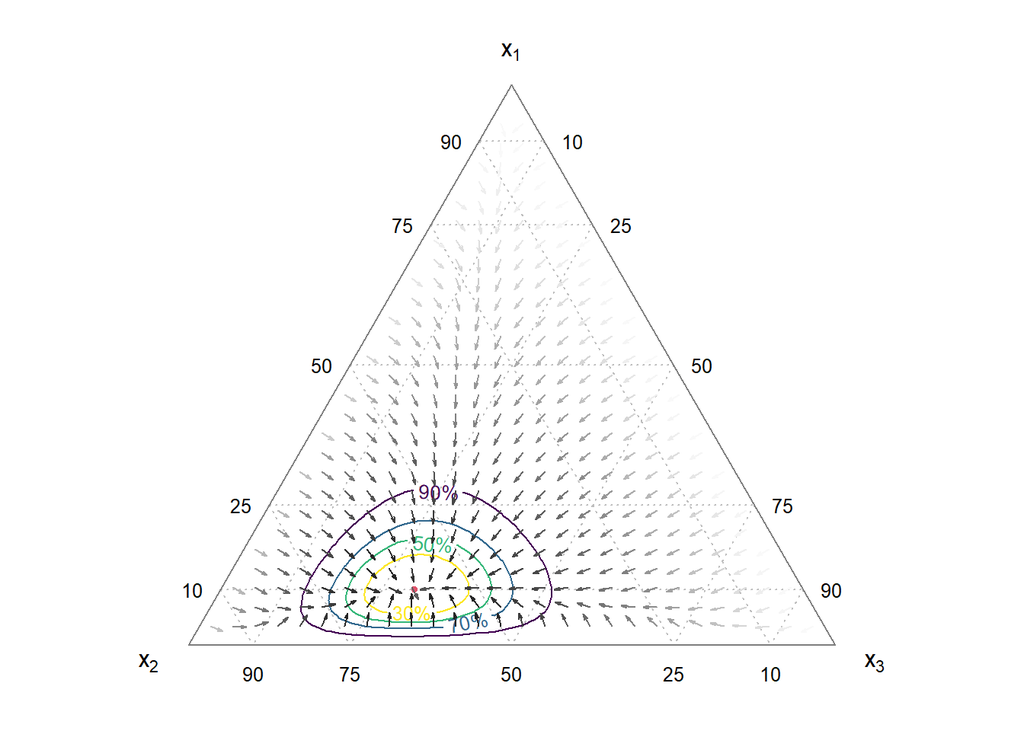

```r
mix <- excases(5)
plotdg(mix)
```

```r
re5 <- exsimu(mix, seed, n, rep)
```

```
## 1  2  3  4  5
```

```r
lapply(re5, function(i) i[, !colnames(i) %in% c("fm1.5", "CV1.75", "CV2", "CV1.75h", "CV2h")])
```

```
## $iae
##       seed        fm       PI       CV   PI_den   CV_den   LK_den        PIh
## [1,] 79856 2.6897652 6.775031 6.774945 7.037677 8.129769 7.701026 0.01034907
## [2,] 11223 3.4953465 6.031847 8.243261 8.255673 8.828690 7.747945 0.01161477
## [3,]  4892 0.5609257 4.953865 5.049188 5.944564 6.309993 6.451125 0.01211810
## [4,] 80128 1.8698070 5.237351 6.406625 5.948718 5.428896 5.356254 0.01051490
## [5,] 83991 0.5032285 5.862662 5.902430 7.609699 8.000573 7.267430 0.01127353
##              CVh     PIh_den     CVh_den     LKh_den
## [1,] 0.010707453 0.008327925 0.006426994 0.006983698
## [2,] 0.006019974 0.006019974 0.005572988 0.006496105
## [3,] 0.009843034 0.008015898 0.007392782 0.007191809
## [4,] 0.016475545 0.006958255 0.008356453 0.008789155
## [5,] 0.010542993 0.006887180 0.006446000 0.007355035
##
## $ise
##       seed         fm        PI        CV   PI_den   CV_den   LK_den        PIh
## [1,] 79856 34.7222846 194.15530 193.35035 208.9372 273.3696 247.2826 0.01034907
## [2,] 11223 53.2877476 151.96309 284.89071 297.2096 339.8980 262.2815 0.01161477
## [3,]  4892  1.4551921  87.39162  89.12764 128.9742 145.5750 152.3729 0.01211810
## [4,] 80128 15.3095571 102.04649 153.51921 150.0850 130.9965 129.0389 0.01051490
## [5,] 83991  0.9602813 137.97298 140.00870 238.4163 263.5984 217.5556 0.01127353
##              CVh     PIh_den     CVh_den     LKh_den
## [1,] 0.010707453 0.008327925 0.006426994 0.006983698
## [2,] 0.006019974 0.006019974 0.005572988 0.006496105
## [3,] 0.009843034 0.008015898 0.007392782 0.007191809
## [4,] 0.016475545 0.006958255 0.008356453 0.008789155
## [5,] 0.010542993 0.006887180 0.006446000 0.007355035
```

## Model 6:

Mode is the same as model 3, but alpha_0 is larger.

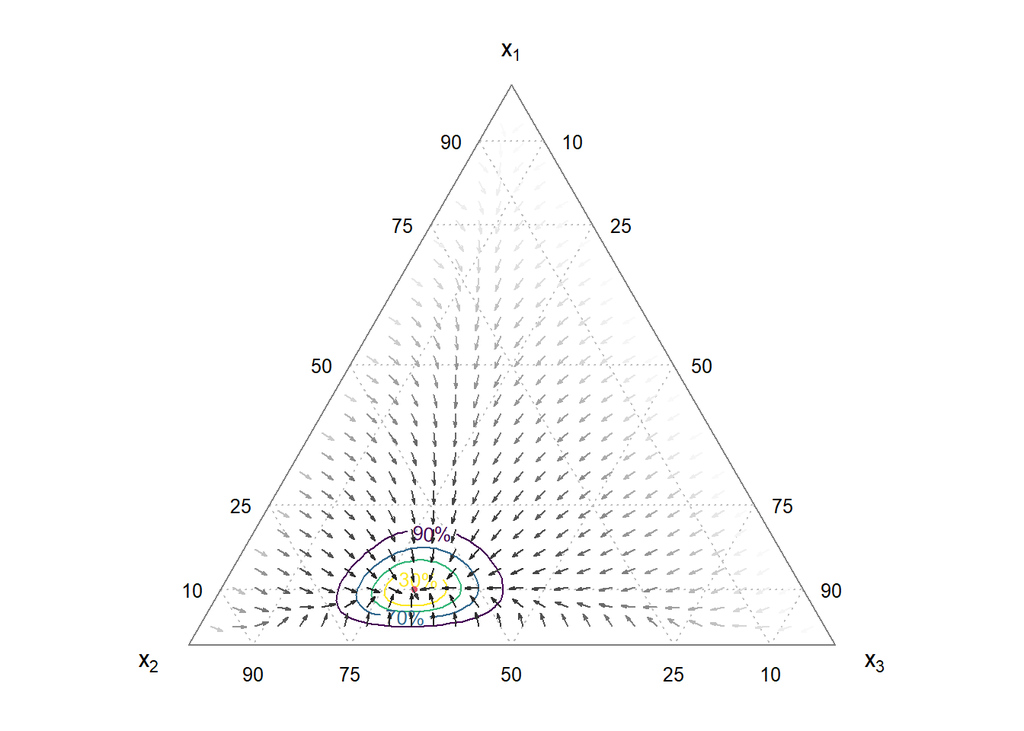

```r
mix <- excases(6)
plotdg(mix)
```

```r
re6 <- exsimu(mix, seed, n, rep)
```

```
## 1  2  3  4  5
```

```r
lapply(re6, function(i) i[, !colnames(i) %in% c("fm1.5", "CV1.75", "CV2", "CV1.75h", "CV2h")])
```

```
## $iae
##       seed       fm       PI       CV   PI_den   CV_den   LK_den         PIh
## [1,] 79856 3.276795 15.64152 15.92256 18.07483 18.07483 16.20109 0.004805521
## [2,] 11223 7.262958 13.14724 14.43782 15.43459 13.33852 17.55053 0.004102514
## [3,]  4892 3.308095 13.09078 14.11828 15.68573 20.02681 17.38693 0.003769181
## [4,] 80128 3.521643 12.45809 16.05518 12.60621 15.21899 13.37541 0.004435848
## [5,] 83991 1.753789 13.93217 17.74188 15.10366 17.50170 15.10366 0.004743867
##              CVh     PIh_den     CVh_den     LKh_den
## [1,] 0.004102514 0.002917459 0.002917459 0.003623352
## [2,] 0.006019974 0.002584126 0.003380871 0.002185055
## [3,] 0.003276646 0.002917459 0.002218192 0.002584126
## [4,] 0.002349425 0.003410463 0.002496316 0.002917459
## [5,] 0.002518388 0.003250793 0.002584126 0.003250793
##
## $ise
##       seed        fm        PI       CV    PI_den   CV_den   LK_den         PIh
## [1,] 79856  59.25378 1303.8466 1362.606 1790.1670 1790.167 1395.302 0.004805521
## [2,] 11223 368.48146  978.9209 1182.209 1368.5875 1025.109 1783.795 0.004102514
## [3,]  4892  72.16256  769.1720  900.969 1142.8523 1973.076 1433.255 0.003769181
## [4,] 80128  72.50192  846.2478 1473.991  874.0942 1327.143 1014.061 0.004435848
## [5,] 83991  21.04482 1257.8311 1957.064 1451.7264 1910.229 1451.726 0.004743867
##              CVh     PIh_den     CVh_den     LKh_den
## [1,] 0.004102514 0.002917459 0.002917459 0.003623352
## [2,] 0.006019974 0.002584126 0.003380871 0.002185055
## [3,] 0.003276646 0.002917459 0.002218192 0.002584126
## [4,] 0.002349425 0.003410463 0.002496316 0.002917459
## [5,] 0.002518388 0.003250793 0.002584126 0.003250793
```